# Exploratory

Will Burton

September 15, 2016

### This Analysis is broken down into four main sections

#### 1. General Exploration:

Get to know general information about the dataset ~ how big is it, what type of variables are there, what do variable distributions look like

#### 2. Categorical Exploration:

What associations exist between categorical variables and the response?

#### 3. Continuous Exploration:

Are the continuous variables highly correlated with eachother? Is there a linear association with the log odds? Should the variables be treated as continuous or cut into categories?

#### 4. Initial Modeling:

What significant interactions exist?

#### 1. General Exploration

```r
#exploratory analysis
library(tibble)
library(sas7bdat)
library(dplyr)
library(ggplot2)
library(rgl)
# library(car)
library(tidyr)

df <- read.sas7bdat('C:/Users/Will/Documents/MSA/fall/logistic_regression/homeworks/MSA_logistic_proj/data/construction.sas7bdat')
df <- data.frame(df)
response <- df$win_bid
```

```r
#look at data structure
str(df)
```

```
## 'data.frame':    543 obs. of  19 variables:
##  $ Estimated_Cost__Millions_       : num  127.6 126.8 96.6 195.8 403.8 ...
##  $ Estimated_Years_to_Complete     : num  0.8 0.27 3.31 2.75 5.93 1.3 2.21 8.74 5.97 5.26 ...
##  $ Bid_Price__Millions_            : num  134 143 107 217 436 ...
##  $ Sector                          : num  9 5 3 7 10 3 5 5 8 3 ...
##  $ Region_of_Country               : Factor w/ 5 levels "Mid-west","Northeast",..: 2 3 5 5 2 4 2 4 2 4 ...
##  $ Number_of_Competitor_Bids       : num  17 20 19 6 1 13 11 8 13 10 ...
##  $ Competitor_A                    : num  1 0 1 0 0 0 0 0 0 0 ...
##  $ Competitor_B                    : num  1 1 0 1 0 1 1 0 1 0 ...
##  $ Competitor_C                    : num  0 0 0 1 0 0 0 0 0 0 ...
##  $ Competitor_D                    : num  0 0 0 0 0 0 0 0 0 0 ...
##  $ Competitor_E                    : num  1 1 1 0 0 1 1 1 1 0 ...
##  $ Competitor_F                    : num  1 1 1 1 0 1 1 1 1 0 ...
##  $ Competitor_G                    : num  0 0 0 0 0 0 0 0 0 0 ...
##  $ Competitor_H                    : num  0 0 1 0 0 1 0 1 0 0 ...
##  $ Competitor_I                    : num  0 1 0 0 0 1 1 1 0 1 ...
##  $ Competitor_J                    : num  1 1 1 1 1 1 1 1 1 1 ...
##  $ Win_Bid                         : Factor w/ 2 levels "No","Yes": 2 1 1 2 2 1 1 1 1 1 ...
##  $ Winning_Bid_Price__Millions_    : num  134 133 103 217 436 ...
##  $ Cost_After_Engineering_Estimate_: num  290 180 210 350 970 230 260 270 70 360 ...
```

```r
#look at first few rows
head(df)
```

```
##   Estimated_Cost__Millions_ Estimated_Years_to_Complete
## 1                     127.6                        0.80
## 2                     126.8                        0.27
## 3                      96.6                        3.31
## 4                     195.8                        2.75
## 5                     403.8                        5.93
## 6                     125.2                        1.30
##   Bid_Price__Millions_ Sector Region_of_Country Number_of_Competitor_Bids
## 1             134.4302      9         Northeast                        17
## 2             142.7565      5         Southeast                        20
## 3             106.5703      3              West                        19
## 4             216.9011      7              West                         6
## 5             436.4237     10         Northeast                         1
## 6             138.4649      3         Southwest                        13
##   Competitor_A Competitor_B Competitor_C Competitor_D Competitor_E
```

[output cut: 20 more lines]

```r
#look at summary
summary(df)
```

```
##  Estimated_Cost__Millions_ Estimated_Years_to_Complete
##  Min.   : 22.6             Min.   : 0.010
##  1st Qu.:100.6             1st Qu.: 1.900
##  Median :145.4             Median : 3.790
##  Mean   :162.2             Mean   : 4.280
##  3rd Qu.:203.4             3rd Qu.: 6.085
##  Max.   :508.2             Max.   :17.420
##  Bid_Price__Millions_     Sector       Region_of_Country
##  Min.   : 24.87       Min.   : 1.000   Mid-west : 50
##  1st Qu.:110.69       1st Qu.: 3.000   Northeast:157
##  Median :160.29       Median : 6.000   Southeast:122
##  Mean   :178.40       Mean   : 5.722   Southwest: 79
##  3rd Qu.:222.45       3rd Qu.: 8.000   West     :135
##  Max.   :564.79       Max.   :10.000
##  Number_of_Competitor_Bids  Competitor_A     Competitor_B
##  Min.   : 0.00             Min.   :0.0000   Min.   :0.000
##  1st Qu.: 9.00             1st Qu.:0.0000   1st Qu.:1.000
##  Median :13.00             Median :0.0000   Median :1.000
##  Mean   :12.12             Mean   :0.3849   Mean   :0.779
##  3rd Qu.:15.00             3rd Qu.:1.0000   3rd Qu.:1.000
##  Max.   :24.00             Max.   :1.0000   Max.   :1.000
##   Competitor_C      Competitor_D     Competitor_E     Competitor_F
##  Min.   :0.00000   Min.   :0.0000   Min.   :0.0000   Min.   :0.0000
##  1st Qu.:0.00000   1st Qu.:0.0000   1st Qu.:1.0000   1st Qu.:0.0000
##  Median :0.00000   Median :0.0000   Median :1.0000   Median :1.0000
##  Mean   :0.05709   Mean   :0.1068   Mean   :0.8103   Mean   :0.6243
##  3rd Qu.:0.00000   3rd Qu.:0.0000   3rd Qu.:1.0000   3rd Qu.:1.0000
##  Max.   :1.00000   Max.   :1.0000   Max.   :1.0000   Max.   :1.0000
##   Competitor_G      Competitor_H     Competitor_I     Competitor_J
##  Min.   :0.00000   Min.   :0.0000   Min.   :0.0000   Min.   :0.0000
##  1st Qu.:0.00000   1st Qu.:0.0000   1st Qu.:0.0000   1st Qu.:0.0000
##  Median :0.00000   Median :0.0000   Median :0.0000   Median :1.0000
##  Mean   :0.09945   Mean   :0.4549   Mean   :0.2302   Mean   :0.6556
##  3rd Qu.:0.00000   3rd Qu.:1.0000   3rd Qu.:0.0000   3rd Qu.:1.0000
##  Max.   :1.00000   Max.   :1.0000   Max.   :1.0000   Max.   :1.0000
##  Win_Bid   Winning_Bid_Price__Millions_ Cost_After_Engineering_Estimate_
##  No :456   Min.   : 23.32               Min.   :  20
##  Yes: 87   1st Qu.:108.67               1st Qu.: 120
##            Median :154.73               Median : 200
##            Mean   :174.01               Mean   : 242
##            3rd Qu.:217.84               3rd Qu.: 320
##            Max.   :554.58               Max.   :1070
```

```r
#idetify number of unique variable levels
sapply(df, function(x) length(unique(x)))
```

```
##        Estimated_Cost__Millions_      Estimated_Years_to_Complete
##                              450                              409
##             Bid_Price__Millions_                           Sector
##                              543                               10
##                Region_of_Country        Number_of_Competitor_Bids
##                                5                               25
##                     Competitor_A                     Competitor_B
##                                2                                2
##                     Competitor_C                     Competitor_D
##                                2                                2
##                     Competitor_E                     Competitor_F
##                                2                                2
##                     Competitor_G                     Competitor_H
##                                2                                2
##                     Competitor_I                     Competitor_J
##                                2                                2
##                          Win_Bid     Winning_Bid_Price__Millions_
##                                2                              537
## Cost_After_Engineering_Estimate_
##                               78
```

```r
#make binary variables and sector, factors
names(df) <- tolower(names(df))

df %>%
  mutate_each(funs(as.factor),c(4,grep('competitor', names(df))) ) -> df
```

look at histograms of each continuous variable, barplots of each factor variable

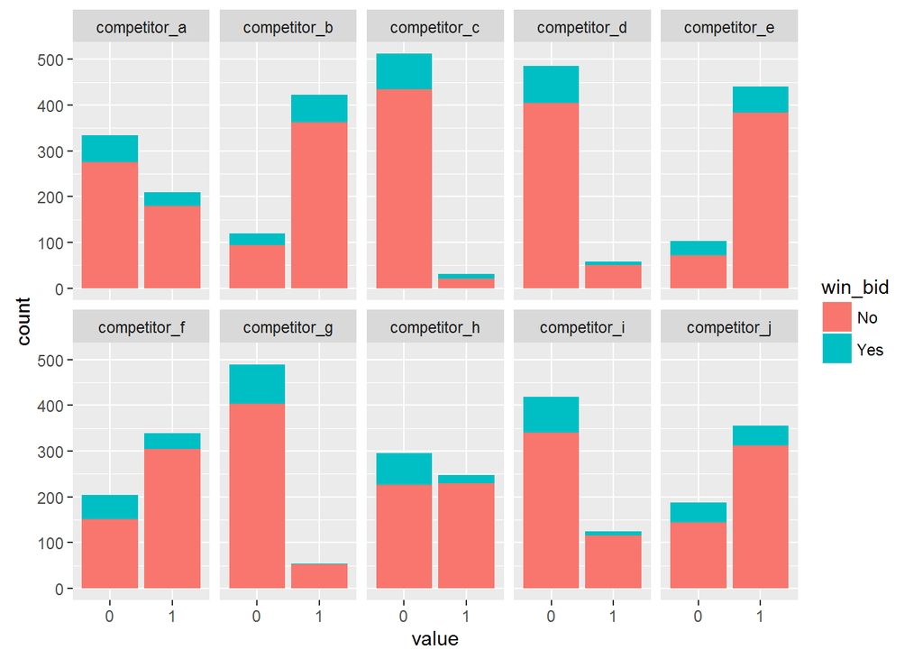

```r
df %>%
  select(grep('^competitor|win_bid', names(df))) -> x
  gather(x,key = competitor, value = value, grep('competitor',names(x)))-> competitors

ggplot(competitors) + geom_bar(aes(value, fill = win_bid)) + facet_wrap(~competitor, nrow = 2)
```

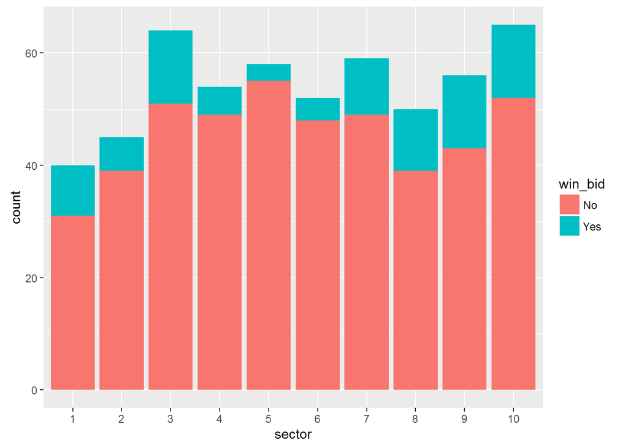

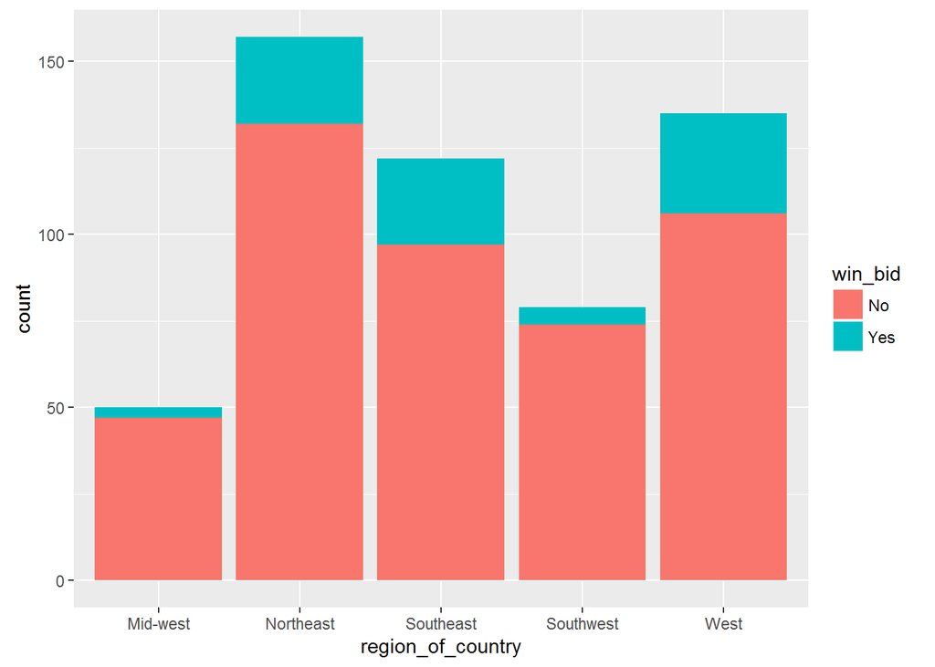

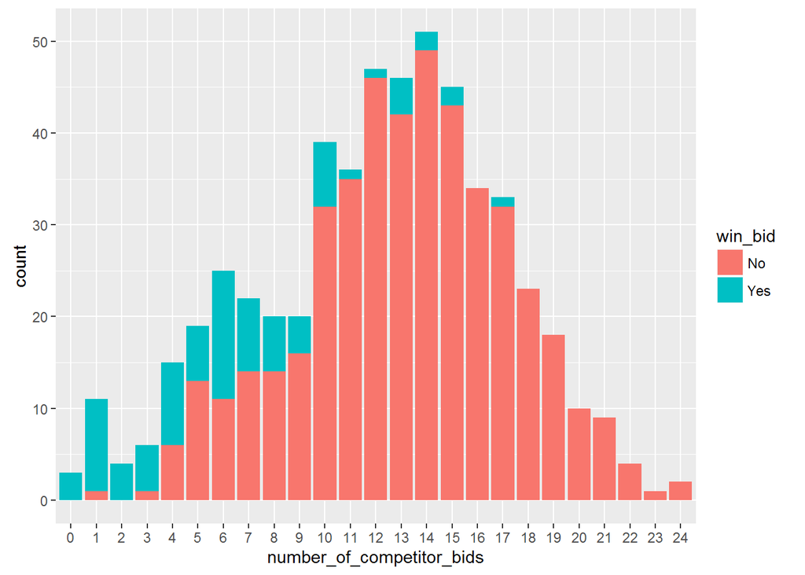

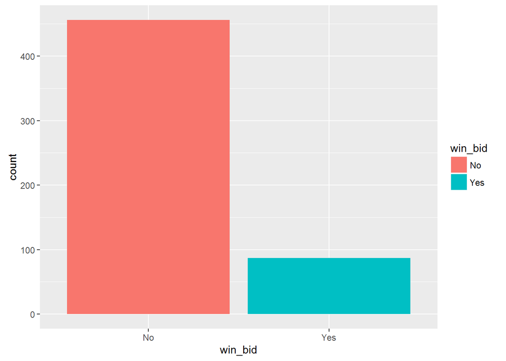

```r
i = 0
factor_df <- df %>% select(-grep('^competitor', names(df)))
for(col in factor_df){
  i <- i + 1
  if(is.factor(col)){
      print(ggplot(factor_df) + geom_bar(aes(col, fill = win_bid) ) + xlab(names(factor_df)[i]))
  }
}
```

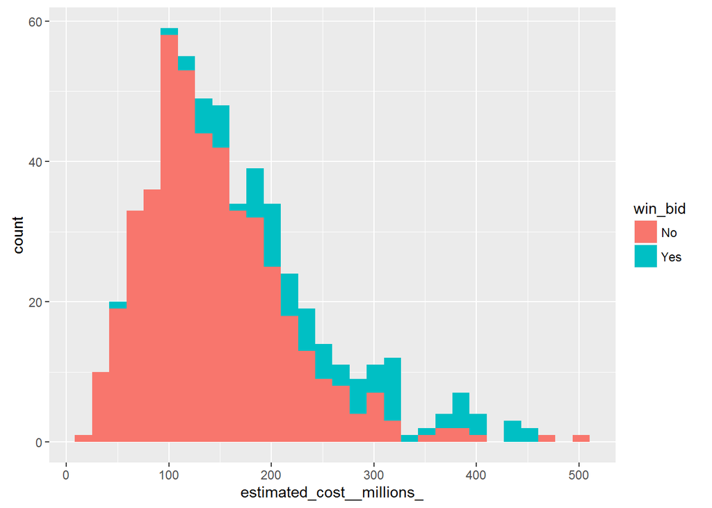

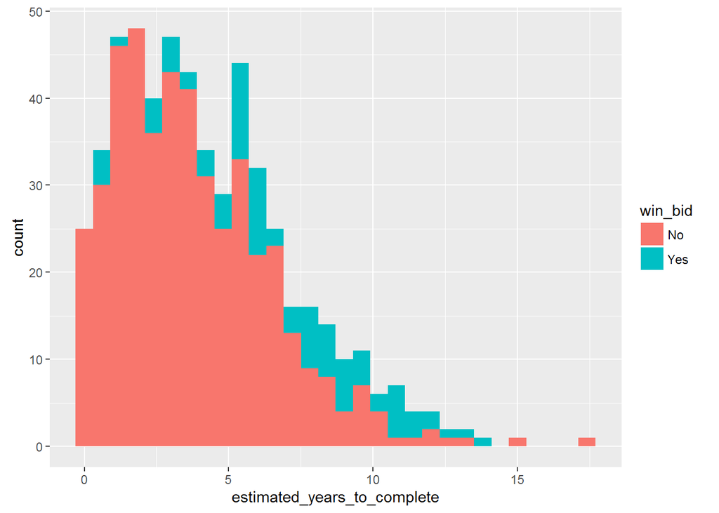

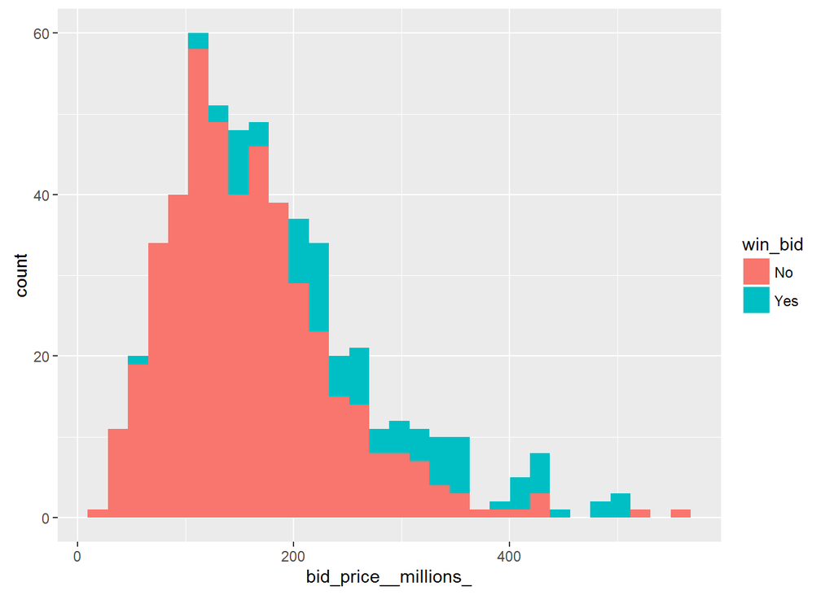

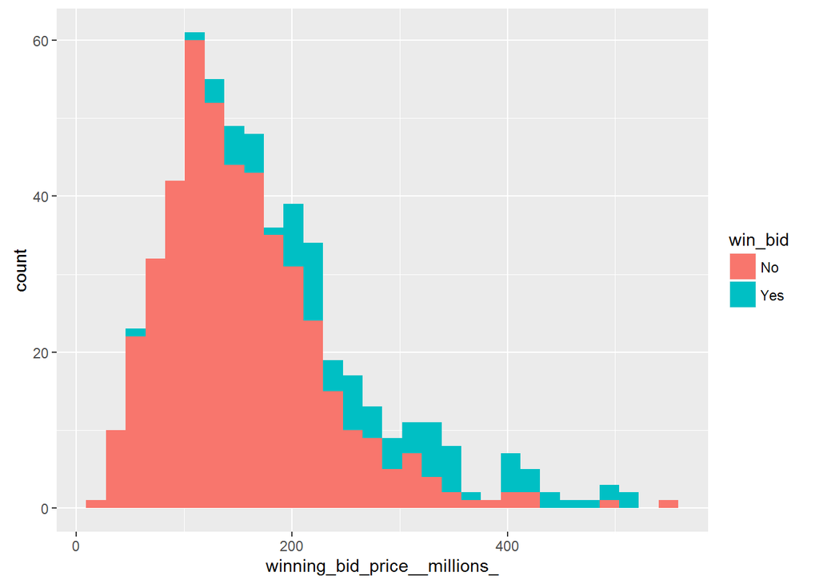

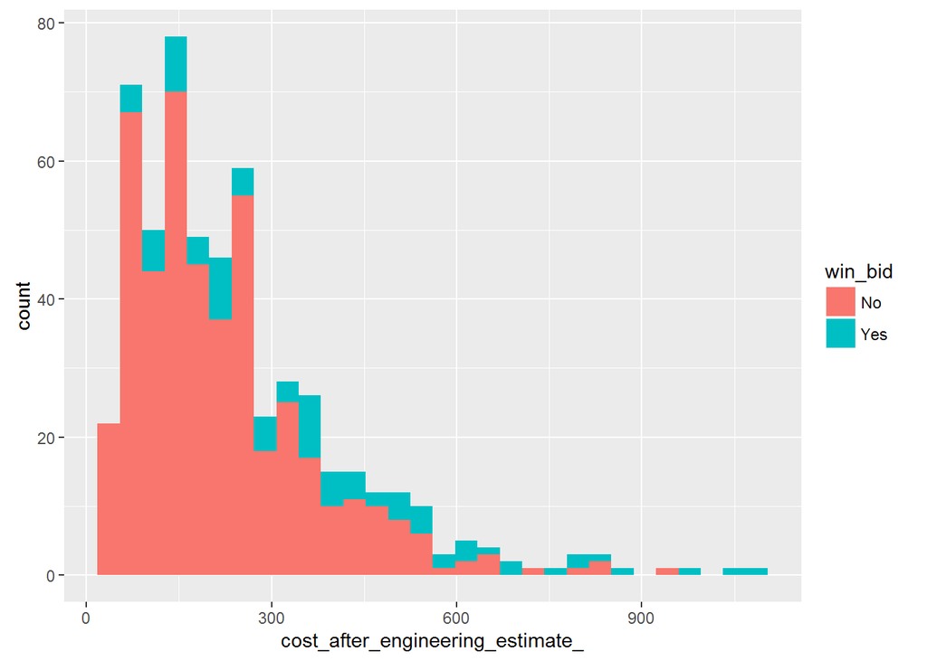

```r
i = 0
for(col in df){
  i <- i + 1
  if(is.numeric(col)){
    print(ggplot(df) + geom_histogram(aes(col, fill = win_bid)) + xlab(names(df)[i]))
  }
}
```

#### 2. Categorical Exploration:

Start out looking more into sector and region_of_country variables

```r
#expore sector variable
table(df$sector,df$win_bid)[,2]/table(df$sector)
```

```
##
##          1          2          3          4          5          6
## 0.22500000 0.13333333 0.20312500 0.09259259 0.05172414 0.07692308
##          7          8          9         10
## 0.16949153 0.22000000 0.23214286 0.20000000
```

potentially combine sectors 1,3,8,9,10 into one sector (around .2)  
potentially combine sectors 4,5,6 into one sector  
potentially combine sectors 7 (remains the same) into one sector

Explore region variable

```r
table(df$region_of_country,df$win_bid)[,2]/table(df$region_of_country)
```

```
##
##   Mid-west  Northeast  Southeast  Southwest       West
## 0.06000000 0.15923567 0.20491803 0.06329114 0.21481481
```

potentially combine Southeast and West  
potentially combine mid-west, southwest

Examine region stratified by sector

```r
table(df$region_of_country, df$sector, df$win_bid)
```

```
## , ,  = No
##
##
##              1  2  3  4  5  6  7  8  9 10
##   Mid-west   2  3  5  5  4  4  6  4  6  8
##   Northeast 14 10 15 14 13 11 16 13 13 13
##   Southeast  6 11  8 13 12 17  7  7  5 11
##   Southwest  8  6 10  4  9  9  9  6  8  5
##   West       1  9 13 13 17  7 11  9 11 15
##
## , ,  = Yes
##
##
##              1  2  3  4  5  6  7  8  9 10
##   Mid-west   0  0  1  0  0  0  0  2  0  0
##   Northeast  2  1  5  0  1  0  3  2  6  5
##   Southeast  4  0  2  3  0  4  0  4  3  5
##   Southwest  0  2  1  0  1  0  0  0  0  1
##   West       3  3  4  2  1  0  7  3  4  2
```

It appears any interaction between these two variables would create a very sparse matrix. Though condensed versions of the variables may not be.. lets find out

```r
df$sector <- as.factor(ifelse(df$sector %in% c(1,3,8,9,10),1,
                   ifelse(df$sector %in% c(4,5,6),2,3)))

df$region_of_country <- as.factor(ifelse(df$region_of_country %in% c('Southeast', 'West'),'SE_W',
                               ifelse(df$region_of_country %in% c('Mid-west', 'Southwest'), 'M_S_W',
                               'Northeast')))

table(df$region_of_country, df$sector, df$win_bid)
```

```
## , ,  = No
##
##
##              1  2  3
##   M_S_W     62 35 24
##   Northeast 68 38 26
##   SE_W      86 79 38
##
## , ,  = Yes
##
##
##              1  2  3
##   M_S_W      5  1  2
##   Northeast 20  1  4
##   SE_W      34 10 10
```

This new table shows no issues of quasi-separation and it appears an interaction may be useful in modeling.

Explore more into the competitor binary variables. The first histogram is looking at the sum of the number of competitors for each observation

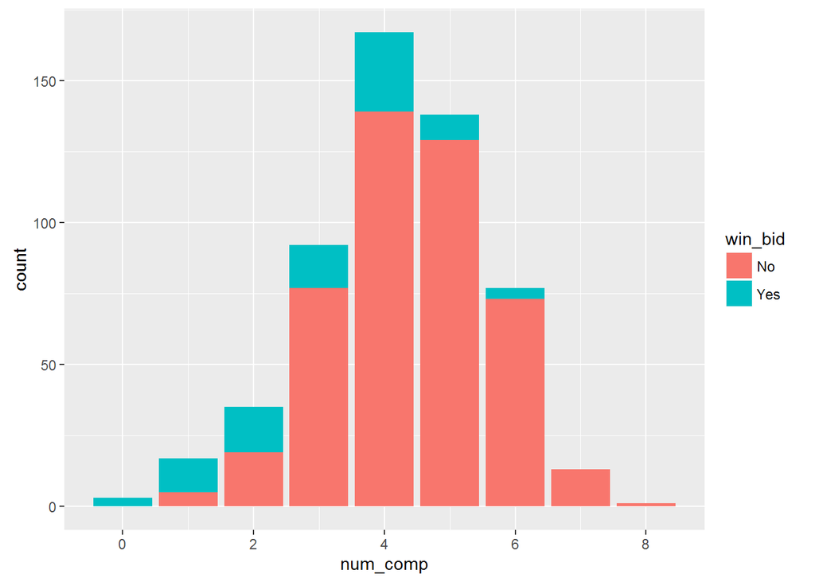

```r
df %>%
  select(c(grep('^competitor',colnames(df))))%>%
  mutate_each(funs(as.numeric(.) -1)) %>%
  mutate(num_comp = rowSums(.)) %>%
  mutate(win_bid = df$win_bid)-> competitor_df
  ggplot(competitor_df) + geom_bar(aes(x = num_comp, fill = win_bid))
```

Look at the correlation between the number_of_competitor_bids and the sum of the binary competitor variables

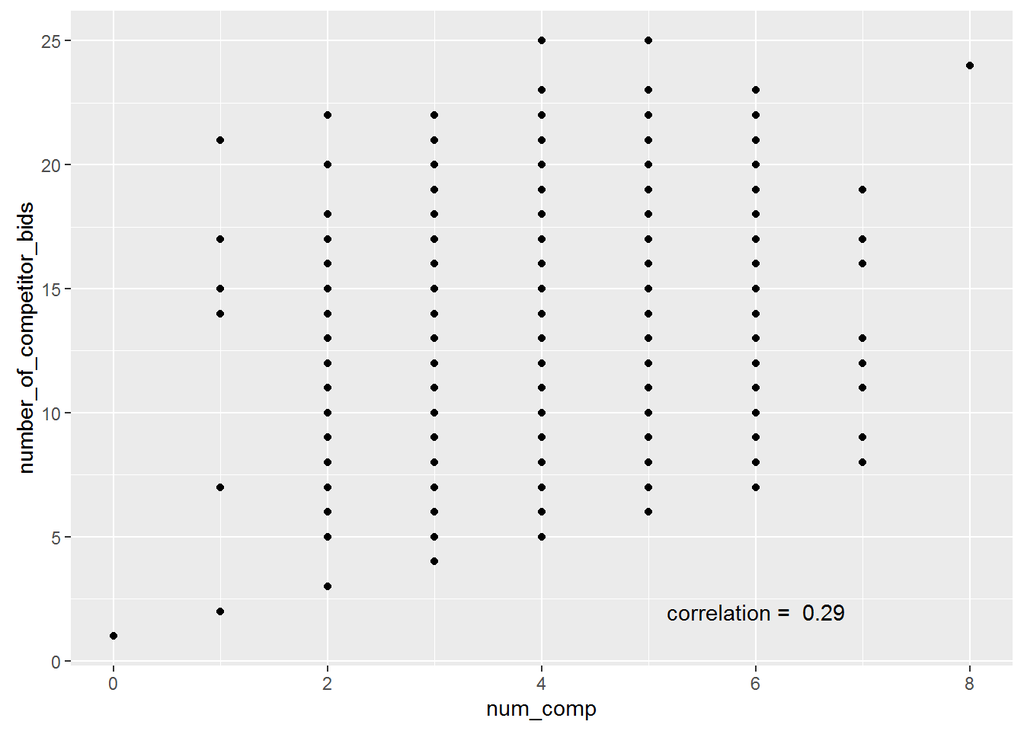

```r
competitor_df %>%
  mutate(number_of_competitor_bids = as.numeric(df$number_of_competitor_bids)) -> competitor_df
ggplot(competitor_df) + geom_point(aes(x = num_comp, y = number_of_competitor_bids)) +
   annotate("text", x = 6, y = 2, label = paste('correlation = ',
                                            round(cor(competitor_df$num_comp, competitor_df$number_of_competitor_bids),2)))
```

This is kind of odd as you would expect the variables to be a little mote correlated.

In attempt to Extract more information out of the number of competitor binary variables we make continuous variables using all the binary variables as inputs. A continuous variable is made using weights based on association with win_bid. The graphs below show the new variable in histograms and density plots.

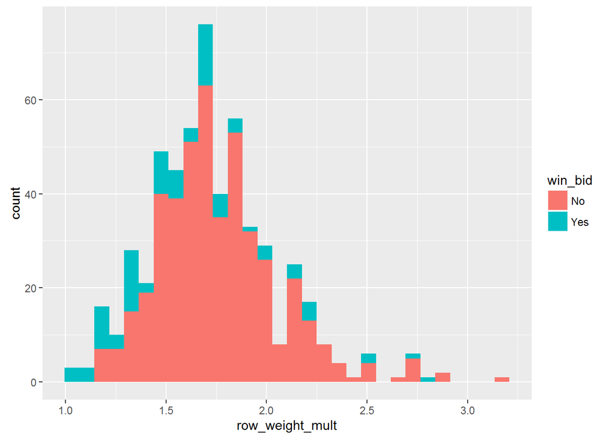

```r
#make a continuous variable that is weighted based on the probability of win_bid

  weights <- sapply(competitor_df[,1:10], function(x){
                 tbl <- table(x, competitor_df$win_bid)
                 pct_win <- tbl[2,2] / (tbl[2,1] + tbl[2,2])
                 weight <- 1/(1-pct_win)
                 return(weight * x)
  }
  )

 #row_weight_mult is the product of all the competitor bid weights multiplied togethor
 row_weight_mult <- apply(weights,1,function(x) {
                  x[x == 0] <-1
                  return(prod(x))})

competitor_df$row_weight_mult <- row_weight_mult

ggplot(competitor_df) + geom_histogram(aes(x = row_weight_mult, fill = win_bid))
```

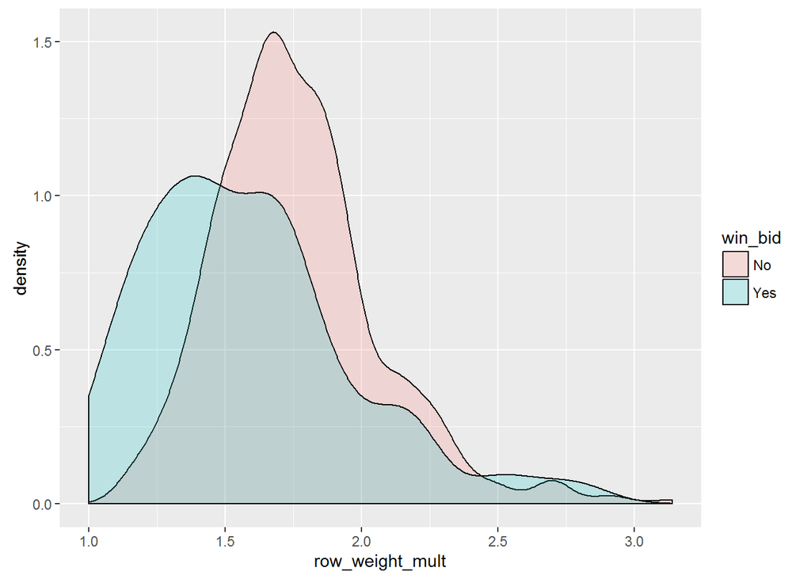

```r
ggplot(competitor_df) + geom_density(aes(x = row_weight_mult, fill = win_bid), alpha = 0.2)
```

```r
df$row_weight_mult <- row_weight_mult
```

#### 3. Explore Continuous Variables

Start out by looking at correlations between continuous variables

```r
cor(df[,sapply(df, is.numeric)])
```

```
##                                  estimated_cost__millions_
## estimated_cost__millions_                        1.0000000
## estimated_years_to_complete                      0.7172078
## bid_price__millions_                             0.9989811
## winning_bid_price__millions_                     0.9987696
## cost_after_engineering_estimate_                 0.7400098
## row_weight_mult                                 -0.2325429
##                                  estimated_years_to_complete
## estimated_cost__millions_                          0.7172078
## estimated_years_to_complete                        1.0000000
## bid_price__millions_                               0.7143390
## winning_bid_price__millions_                       0.7169378
## cost_after_engineering_estimate_                   0.4906397
## row_weight_mult                                   -0.1526280
##                                  bid_price__millions_
## estimated_cost__millions_                   0.9989811
## estimated_years_to_complete                 0.7143390
## bid_price__millions_                        1.0000000
## winning_bid_price__millions_                0.9986710
## cost_after_engineering_estimate_            0.7386029
## row_weight_mult                            -0.2333073
##                                  winning_bid_price__millions_
## estimated_cost__millions_                           0.9987696
## estimated_years_to_complete                         0.7169378
## bid_price__millions_                                0.9986710
## winning_bid_price__millions_                        1.0000000
## cost_after_engineering_estimate_                    0.7366741
## row_weight_mult                                    -0.2344814
##                                  cost_after_engineering_estimate_
## estimated_cost__millions_                               0.7400098
## estimated_years_to_complete                             0.4906397
## bid_price__millions_                                    0.7386029
## winning_bid_price__millions_                            0.7366741
## cost_after_engineering_estimate_                        1.0000000
## row_weight_mult                                        -0.1804561
##                                  row_weight_mult
## estimated_cost__millions_             -0.2325429
## estimated_years_to_complete           -0.1526280
## bid_price__millions_                  -0.2333073
## winning_bid_price__millions_          -0.2344814
## cost_after_engineering_estimate_      -0.1804561
## row_weight_mult                        1.0000000
```

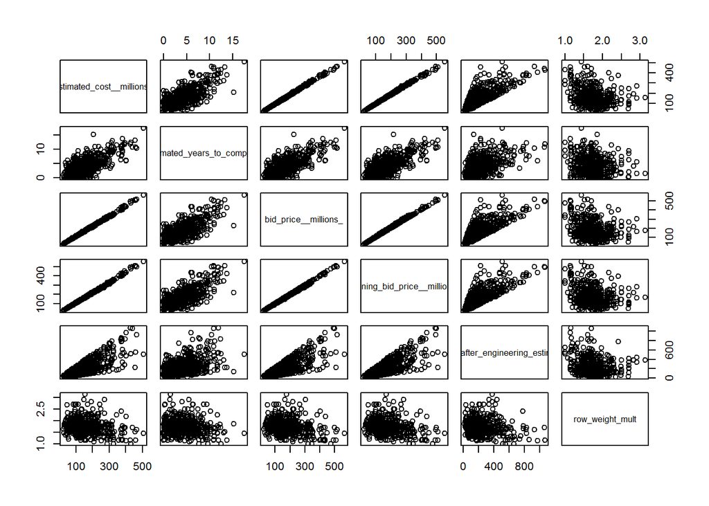

```r
pairs(df[,sapply(df, is.numeric)])
```

The variables winning_bid_price_*millions*, bid_price_*millions*, and estimated_cost_*millions* are all highly correlated.

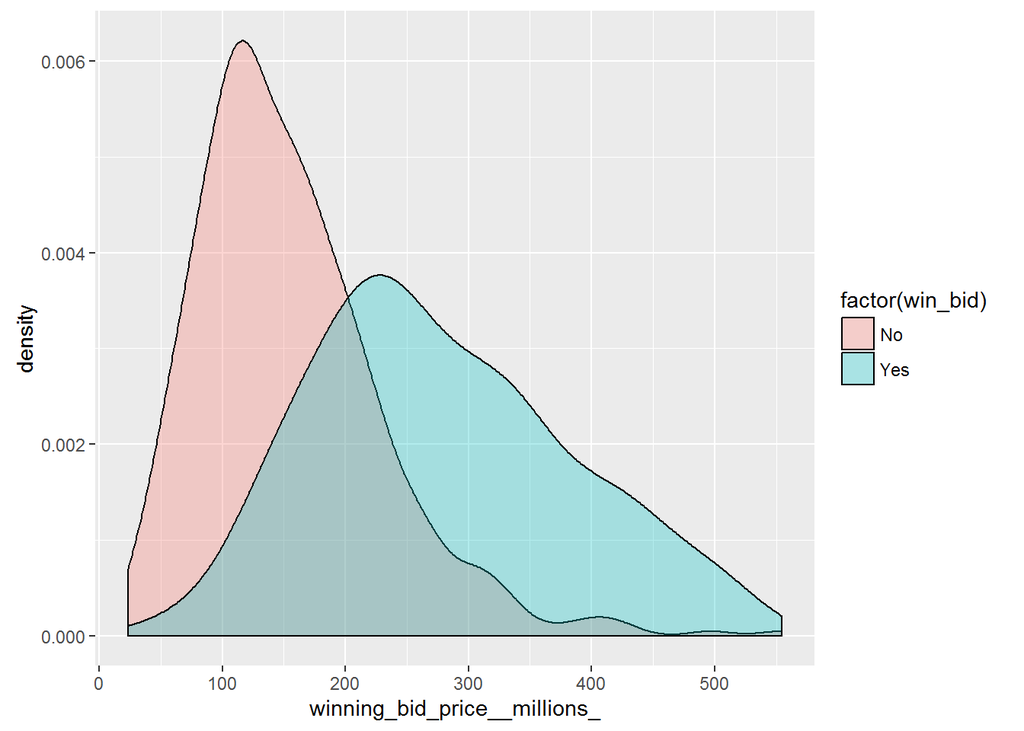

```r
ggplot(df, aes(x = winning_bid_price__millions_ , fill = factor(win_bid))) + geom_density(alpha = .3)
```

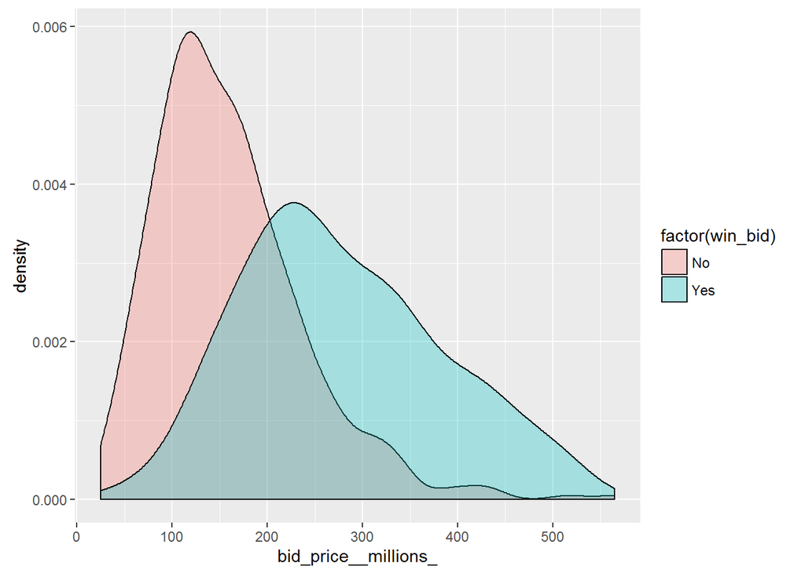

```r
ggplot(df, aes(x = bid_price__millions_ , fill = factor(win_bid))) + geom_density(alpha = .3)
```

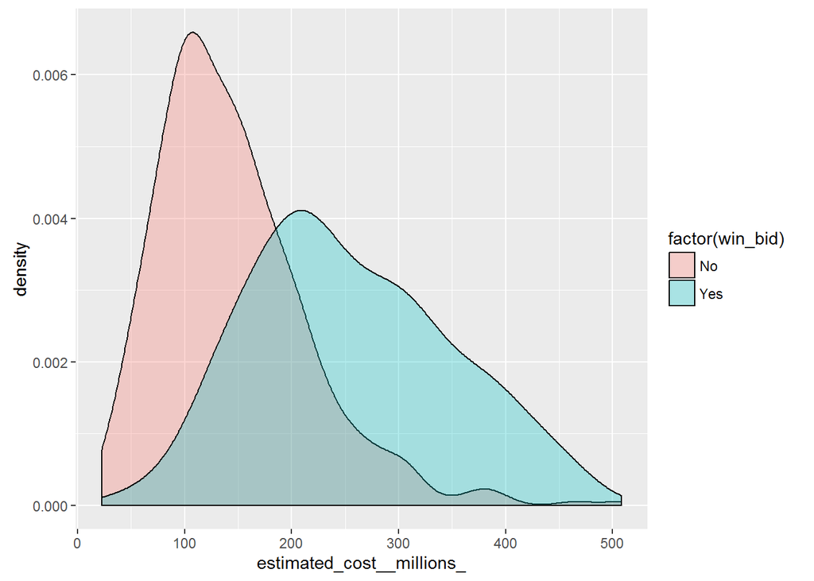

```r
ggplot(df, aes(x = estimated_cost__millions_ , fill = factor(win_bid))) + geom_density(alpha = .3)
```

There may be no improvement in accuracy by keeping all three, two will most likely be eliminated. Instead of simply eliminating two, principal components is performed to create a variable that retains information of all three.

```r
df  %>%
  select(estimated_cost__millions_,
         bid_price__millions_,
         winning_bid_price__millions_) -> pca_df

plot3d(pca_df$estimated_cost__millions_, pca_df$bid_price__millions_, pca_df$winning_bid_price__millions_ )

#the 3 variables are converted into a single variable using PCA
pca = prcomp(pca_df, scale=F)
new_var <- pca$x[,1]
df$pc <- new_var
summary(pca)
```

```
## Importance of components:
##                             PC1     PC2     PC3
## Standard deviation     156.4762 3.42433 2.79623
## Proportion of Variance   0.9992 0.00048 0.00032
## Cumulative Proportion    0.9992 0.99968 1.00000
```

The first principal component accoiunted for 99.92% of the variation. We will keep this variable and eliminate the variables used to create it

The new variable created from prinipal components is plotted along with the remaining continuous variables in density plots

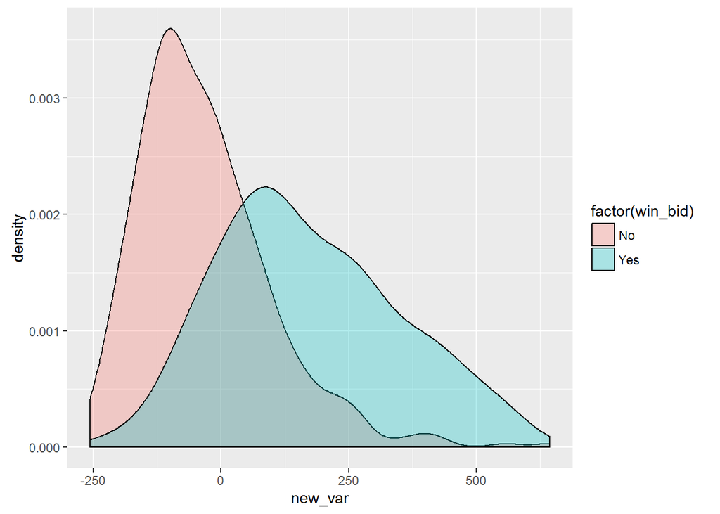

```r
#new variable plottes in density plot
ggplot(df, aes(x = new_var , fill = factor(win_bid))) + geom_density(alpha = .3)
```

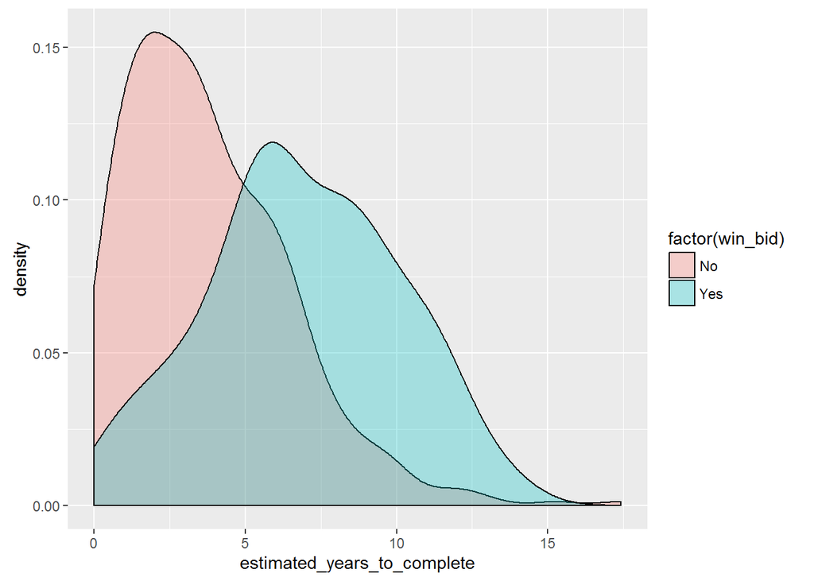

```r
#The remaining variables are both very interesting
ggplot(df, aes(x = estimated_years_to_complete, fill = factor(win_bid))) + geom_density(alpha = .3)
```

It appears the company is focused on completing long projects, and less on short term projects… Or less companies compete for long term projects

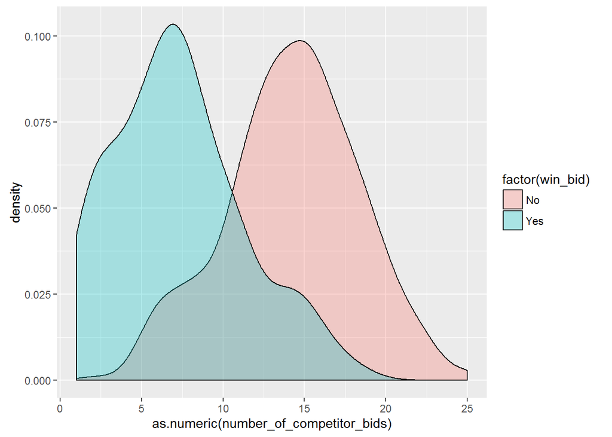

```r
ggplot(df, aes(x = as.numeric(number_of_competitor_bids), fill = factor(win_bid))) + geom_density(alpha = .3)
```

The number of competitors appears to be an extremely good predictor of whether a bid is won or not.

Now that the continuous variables have been examined… Should the continuous variables be treated as continuous or cut into different levels as factors, OR should additional polynomial terms be added? To answer these questions, each continuous variable is cut into 25 different levels and plotted against the log odds of winning a bid. If the log odds are linear, then the points will form approximately a straight line. If the log odds are non-linear, then the points will display a non-linear pattern. If There appears to be some step type pattern then we may need to convert the continuous into a categorical variable

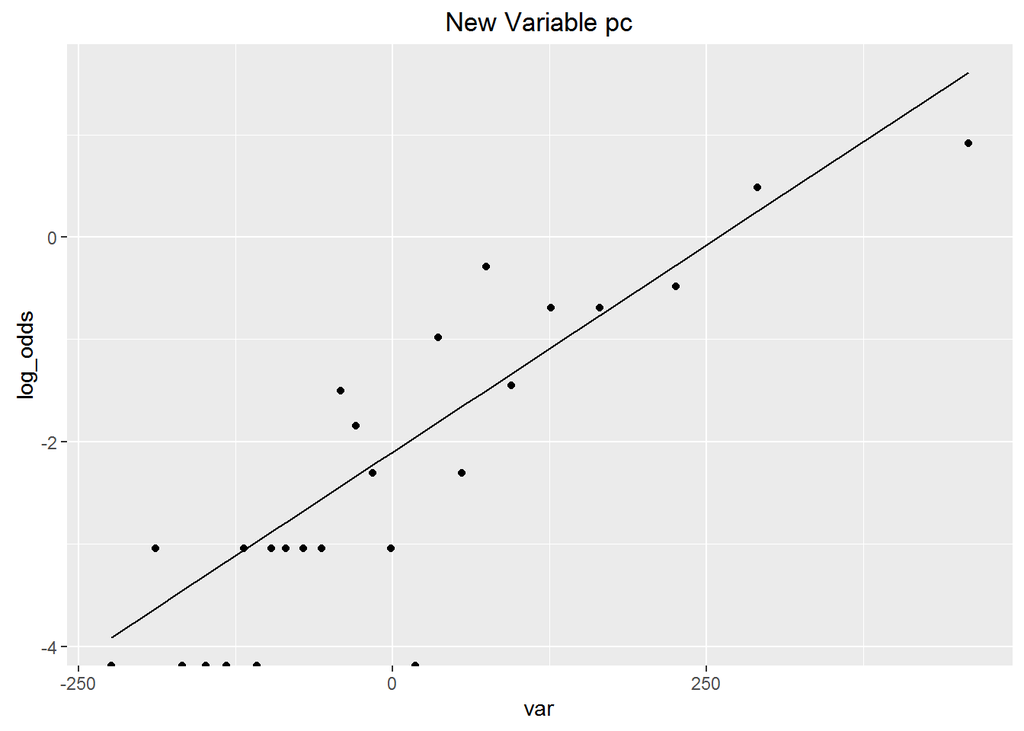

```
##        var   prob_win  n       odds   log_odds  pred_prob pred_log_odds
## 1  -223.73 0.00000000 22 0.00000000       -Inf 0.01956229    -3.9143955
## 2  -188.57 0.04545455 22 0.04761905 -3.0445224 0.02583951    -3.6296715
## 3  -166.97 0.00000000 22 0.00000000       -Inf 0.03062735    -3.4547557
## 4  -148.33 0.00000000 22 0.00000000       -Inf 0.03544072    -3.3038099
## 5  -131.94 0.00000000 22 0.00000000       -Inf 0.04026848    -3.1710844
## 6  -118.41 0.04545455 22 0.04761905 -3.0445224 0.04472276    -3.0615191
## 7  -108.08 0.00000000 22 0.00000000       -Inf 0.04843583    -2.9778673
## 8   -96.06 0.04545455 22 0.04761905 -3.0445224 0.05312448    -2.8805299
## 9   -84.49 0.04545455 22 0.04761905 -3.0445224 0.05803966    -2.7868366
## 10  -70.92 0.04545455 22 0.04761905 -3.0445224 0.06434742    -2.6769473
## 11  -56.27 0.04545455 22 0.04761905 -3.0445224 0.07187004    -2.5583123
## 12  -41.22 0.18181818 22 0.22222222 -1.5040774 0.08043598    -2.4364381
## 13  -29.20 0.13636364 22 0.15789474 -1.8458267 0.08793601    -2.3391007
## 14  -15.43 0.09090909 22 0.10000000 -2.3025851 0.09729994    -2.2275919
## 15   -1.34 0.04545455 22 0.04761905 -3.0445224 0.10779239    -2.1134918
## 16   18.43 0.00000000 22 0.00000000       -Inf 0.12418362    -1.9533952
## 17   36.77 0.27272727 22 0.37500000 -0.9808293 0.14125821    -1.8048788
## 18   55.47 0.09090909 22 0.10000000 -2.3025851 0.16064362    -1.6534470
## 19   74.42 0.42857143 21 0.75000000 -0.2876821 0.18242689    -1.4999908
## 20   94.53 0.19047619 21 0.23529412 -1.4469190 0.20798061    -1.3371410
## 21  126.47 0.33333333 21 0.50000000 -0.6931472 0.25379143    -1.0784924
## 22  165.23 0.33333333 21 0.50000000 -0.6931472 0.31764499    -0.7646157
## 23  225.82 0.38095238 21 0.61538462 -0.4855078 0.43193500    -0.2739607
## 24  290.60 0.61904762 21 1.62500000  0.4855078 0.56233025     0.2506247
## 25  458.46 0.71428571 21 2.50000000  0.9162907 0.83340404     1.6099471
```

```r
convert_to_factor <- function(var, n_levels){
  obs_per_level <- rep(floor(length(var)/n_levels),n_levels)
  remainder <- rep(1,(length(var) - sum(obs_per_level)))
  obs_per_level[1:length(remainder)] <- obs_per_level[1] + remainder
  var <- data.frame(value = var)
  var$index <- 1:nrow(var)
  var$cut <- NA
  var <- var[order(var[,1]),]
  for(i in 0:(n_levels-1)){
    min <- ifelse(i == 0,1,sum(obs_per_level[1:i]) + 1)
    max <- sum(obs_per_level[1:(i + 1)])
    var$cut[min:max] <- i
  }
  var$cut <- as.factor(var$cut)
  var %>%
    group_by(cut) %>%
    mutate(mean_cut = round(mean(value),2)) %>%
    arrange(index) -> var
  return(var$mean_cut)
}

plot_continuous <- function(cut_var, response, i, title){
    comp_tbl <- table(cut_var,response)[,2]/table(cut_var)
      unique_cut_var <- unique(cut_var[order(cut_var)])
      comp_pct <- data.frame(var = unique_cut_var , prob_win = as.numeric(comp_tbl),
                             n = as.numeric(table(cut_var)),
                             odds = as.numeric(comp_tbl)/(1-as.numeric(comp_tbl)),
                             log_odds = log(as.numeric(comp_tbl)/(1-as.numeric(comp_tbl))))

      log_mod <- glm(response ~ poly(cut_var,i) , family = "binomial")
      probs <- predict(log_mod,data.frame(cut_var = unique_cut_var), type = 'response')
      comp_pct$pred_prob <- probs
      comp_pct$pred_log_odds <- log(probs/(1-probs))

      #It appears like the number of competitors can be modeled fine as a continuous variable
      print(ggplot(comp_pct, aes(x=var, y=log_odds))+ geom_point() +
        geom_line(aes(x = var, y = pred_log_odds)) + xlim(min(comp_pct$var) - 1,max(comp_pct$var) + 1) +
          ggtitle(title))
      print(comp_pct)
}

#all the log odds appear to be fairly linear

plot_continuous(convert_to_factor(df$pc,25),df$win_bid, i = 1, 'New Variable pc')
```

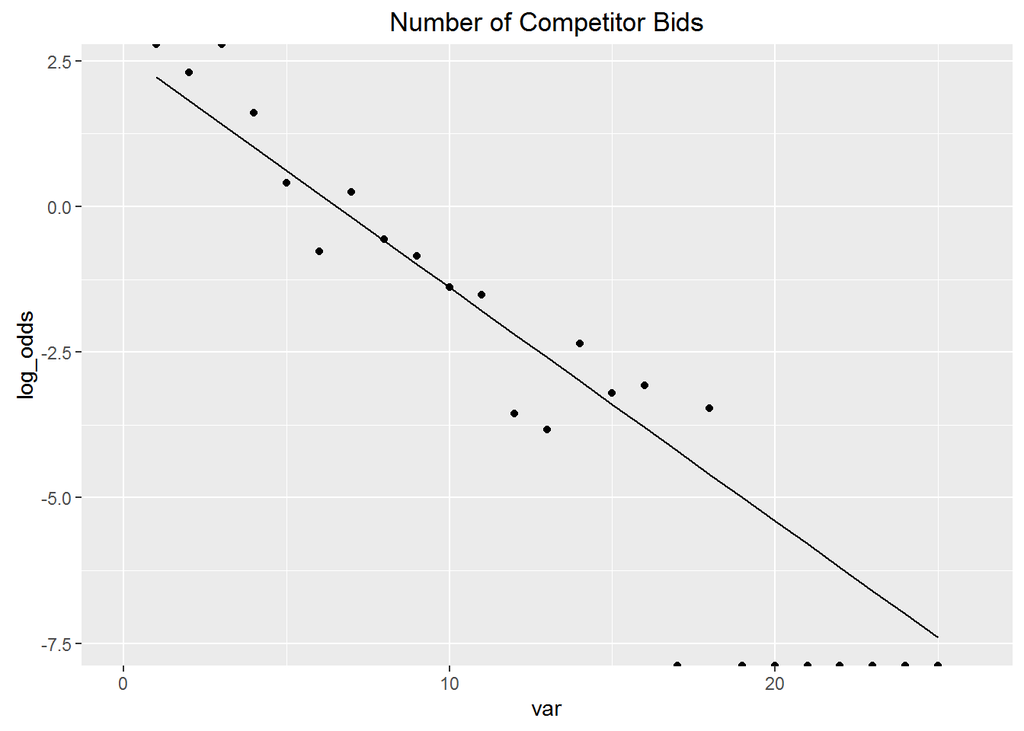

```
##    var   prob_win  n        odds   log_odds    pred_prob pred_log_odds
## 1    1 1.00000000  3         Inf        Inf 0.9015457132     2.2145184
## 2    2 0.90909091 11 10.00000000  2.3025851 0.8598314848     1.8138910
## 3    3 1.00000000  4         Inf        Inf 0.8042802019     1.4132637
## 4    4 0.83333333  6  5.00000000  1.6094379 0.7335357650     1.0126363
## 5    5 0.60000000 15  1.50000000  0.4054651 0.6483989376     0.6120090
## 6    6 0.31578947 19  0.46153846 -0.7731899 0.5526495056     0.2113816
## 7    7 0.56000000 25  1.27272727  0.2411621 0.4528292580    -0.1892458
## 8    8 0.36363636 22  0.57142857 -0.5596158 0.3566639681    -0.5898731
## 9    9 0.30000000 20  0.42857143 -0.8472979 0.2708132358    -0.9905005
## 10  10 0.20000000 20  0.25000000 -1.3862944 0.1992277655    -1.3911278
## 11  11 0.17948718 39  0.21875000 -1.5198258 0.1428576663    -1.7917552
## 12  12 0.02777778 36  0.02857143 -3.5553481 0.1004366269    -2.1923826
## 13  13 0.02127660 47  0.02173913 -3.8286414 0.0695896475    -2.5930099
## 14  14 0.08695652 46  0.09523810 -2.3513753 0.0477141490    -2.9936373
## 15  15 0.03921569 51  0.04081633 -3.1986731 0.0324751907    -3.3942646
## 16  16 0.04444444 45  0.04651163 -3.0680529 0.0219908624    -3.7948920
## 17  17 0.00000000 34  0.00000000       -Inf 0.0148393929    -4.1955194
## 18  18 0.03030303 33  0.03125000 -3.4657359 0.0099898392    -4.5961467
## 19  19 0.00000000 23  0.00000000       -Inf 0.0067143312    -4.9967741
## 20  20 0.00000000 18  0.00000000       -Inf 0.0045079195    -5.3974014
## 21  21 0.00000000 10  0.00000000       -Inf 0.0030243541    -5.7980288
## 22  22 0.00000000  9  0.00000000       -Inf 0.0020280384    -6.1986562
## 23  23 0.00000000  4  0.00000000       -Inf 0.0013594923    -6.5992835
## 24  24 0.00000000  1  0.00000000       -Inf 0.0009111323    -6.9999109
## 25  25 0.00000000  2  0.00000000       -Inf 0.0006105509    -7.4005382
```

```r
plot_continuous(as.numeric(df$number_of_competitor_bids), df$win_bid, i = 1, 'Number of Competitor Bids')
```

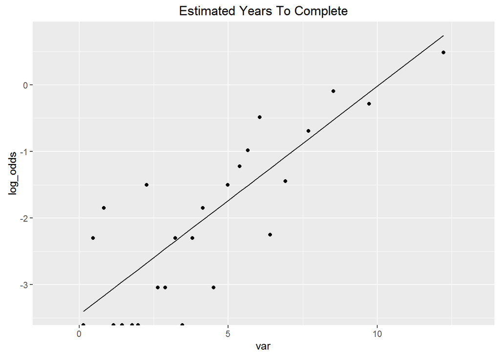

```
##      var   prob_win  n       odds    log_odds  pred_prob pred_log_odds
## 1   0.14 0.00000000 22 0.00000000        -Inf 0.03225791    -3.4012024
## 2   0.46 0.09090909 22 0.10000000 -2.30258509 0.03586393    -3.2915005
## 3   0.82 0.13636364 22 0.15789474 -1.84582669 0.04038453    -3.1680859
## 4   1.15 0.00000000 22 0.00000000        -Inf 0.04500400    -3.0549558
## 5   1.44 0.00000000 22 0.00000000        -Inf 0.04947540    -2.9555385
## 6   1.77 0.00000000 22 0.00000000        -Inf 0.05507506    -2.8424084
## 7   1.97 0.00000000 22 0.00000000        -Inf 0.05875403    -2.7738448
## 8   2.26 0.18181818 22 0.22222222 -1.50407740 0.06449931    -2.6744274
## 9   2.63 0.04545455 22 0.04761905 -3.04452244 0.07258892    -2.5475846
## 10  2.89 0.04545455 22 0.04761905 -3.04452244 0.07882268    -2.4584518
## 11  3.22 0.09090909 22 0.10000000 -2.30258509 0.08743834    -2.3453218
## 12  3.46 0.00000000 22 0.00000000        -Inf 0.09423012    -2.2630454
## 13  3.80 0.09090909 22 0.10000000 -2.30258509 0.10465995    -2.1464871
## 14  4.14 0.13636364 22 0.15789474 -1.84582669 0.11609622    -2.0299289
## 15  4.51 0.04545455 22 0.04761905 -3.04452244 0.12975959    -1.9030861
## 16  4.98 0.18181818 22 0.22222222 -1.50407740 0.14906397    -1.7419614
## 17  5.38 0.22727273 22 0.29411765 -1.22377543 0.16730707    -1.6048341
## 18  5.65 0.27272727 22 0.37500000 -0.98082925 0.18060217    -1.5122731
## 19  6.06 0.38095238 21 0.61538462 -0.48550782 0.20234249    -1.3717176
## 20  6.40 0.09523810 21 0.10526316 -2.25129180 0.22180832    -1.2551593
## 21  6.92 0.19047619 21 0.23529412 -1.44691898 0.25409430    -1.0768937
## 22  7.69 0.33333333 21 0.50000000 -0.69314718 0.30726785    -0.8129236
## 23  8.53 0.47619048 21 0.90909091 -0.09531018 0.37169406    -0.5249561
## 24  9.73 0.42857143 21 0.75000000 -0.28768207 0.47163696    -0.1135741
## 25 12.23 0.61904762 21 1.62500000  0.48550782 0.67775460     0.7434719
```

```r
plot_continuous(convert_to_factor(df$estimated_years_to_complete,25),df$win_bid, i= 1, 'Estimated Years To Complete')
```

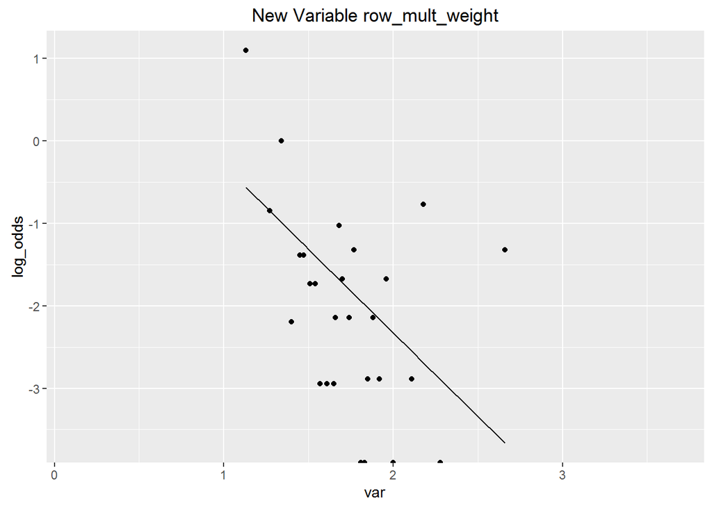

```
##     var   prob_win  n       odds   log_odds  pred_prob pred_log_odds
## 1  1.13 0.75000000 20 3.00000000  1.0986123 0.36231222    -0.5653424
## 2  1.27 0.30000000 20 0.42857143 -0.8472979 0.29966385    -0.8488991
## 3  1.34 0.50000000 20 1.00000000  0.0000000 0.27077829    -0.9906774
## 4  1.40 0.10000000 20 0.11111111 -2.1972246 0.24746065    -1.1122017
## 5  1.45 0.20000000 20 0.25000000 -1.3862944 0.22908731    -1.2134719
## 6  1.47 0.20000000 20 0.25000000 -1.3862944 0.22201194    -1.2539800
## 7  1.51 0.15000000 20 0.17647059 -1.7346011 0.20833413    -1.3349962
## 8  1.54 0.15000000 20 0.17647059 -1.7346011 0.19849006    -1.3957584
## 9  1.57 0.05000000 20 0.05263158 -2.9444390 0.18900008    -1.4565205
## 10 1.61 0.05000000 20 0.05263158 -2.9444390 0.17689365    -1.5375367
## 11 1.65 0.05000000 20 0.05263158 -2.9444390 0.16540454    -1.6185529
## 12 1.66 0.10526316 19 0.11764706 -2.1400662 0.16262747    -1.6388069
## 13 1.68 0.26315789 19 0.35714286 -1.0296194 0.15718619    -1.6793150
## 14 1.70 0.15789474 38 0.18750000 -1.6739764 0.15189395    -1.7198231
## 15 1.74 0.10526316 19 0.11764706 -2.1400662 0.14174893    -1.8008393
## 16 1.77 0.21052632 19 0.26666667 -1.3217558 0.13451650    -1.8616014
## 17 1.81 0.00000000 19 0.00000000       -Inf 0.12536057    -1.9426176
## 18 1.83 0.00000000 19 0.00000000       -Inf 0.12098603    -1.9831257
## 19 1.85 0.05263158 19 0.05555556 -2.8903718 0.11674377    -2.0236338
## 20 1.88 0.10526316 19 0.11764706 -2.1400662 0.11062273    -2.0843959
## 21 1.92 0.05263158 19 0.05555556 -2.8903718 0.10289978    -2.1654121
## 22 1.96 0.15789474 19 0.18750000 -1.6739764 0.09565800    -2.2464283
## 23 2.00 0.00000000 19 0.00000000       -Inf 0.08887538    -2.3274445
## 24 2.11 0.05263158 19 0.05555556 -2.8903718 0.07241043    -2.5502390
## 25 2.18 0.31578947 19 0.46153846 -0.7731899 0.06344604    -2.6920173
## 26 2.28 0.00000000 19 0.00000000       -Inf 0.05242325    -2.8945578
## 27 2.66 0.21052632 19 0.26666667 -1.3217558 0.02498416    -3.6642116
```

```r
plot_continuous(convert_to_factor(df$row_weight_mult,28),df$win_bid, i = 1, 'New Variable row_mult_weight')
```

It appears they can be treated as continuous.. transforming into factor or adding additional polynomial terms does not to appear to add much benefit.

#### 4. Initial modeling:

Now that we have examined the continuous variables, lets look into the possibility of adding interaction terms between all binary and continuous variables. The following script creates a logistic regression model for each possible two way interaction and extracts just the significance on the interaction term. The table returned contains only significant interactions found

```r
var_levels <- sapply(df, function(x) length(levels(x)))
var_levels <- var_levels[var_levels <= 2]
interactions_tbl <- df[,names(df) %in% names(var_levels)]
interactions_tbl %>% select(-win_bid) -> interactions_tbl
significance_tbl <- NULL

for(i in 1:(ncol(interactions_tbl)-1)){
  for(j in (i+1):ncol(interactions_tbl)){
    var1 <- interactions_tbl[,i]
    var1_name <- names(interactions_tbl)[i]
    var2 <- interactions_tbl[,j]
    var2_name <- names(interactions_tbl)[j]
    interactions <-glm(df$win_bid~ var1 + var2 + I(as.numeric(as.character(var1))*as.numeric(as.character(var2))), family = binomial)
    interactions <- summary(interactions)
    interactions <- interactions$coefficients
    if(nrow(interactions) == 3){next}
    rownames(interactions) <- c('intercept', var1_name, var2_name, paste0(var1_name, '*', var2_name))
    interactions <- data.frame(interactions)[4,]
    interactions <- rownames_to_column(interactions, 'variable')
    significance_tbl <- rbind(significance_tbl,interactions)
  }
}

significance_tbl %>%
  filter(Pr...z.. < .001) -> significance_tbl

significance_tbl
```

```
##                                                   variable      Estimate
## 1   estimated_cost__millions_*winning_bid_price__millions_ -6.052694e-05
## 2 estimated_years_to_complete*winning_bid_price__millions_ -1.294033e-03
## 3                             competitor_j*row_weight_mult  3.417399e+00
##     Std..Error   z.value     Pr...z..
## 1 1.515459e-05 -3.993969 6.497643e-05
## 2 3.901479e-04 -3.316775 9.106300e-04
## 3 1.019023e+00  3.353605 7.976616e-04
```

The significant interactions are now created and added to the dataset (except competitor_j*row_weight_mult… It just doesn’t make any sense to add it to the model)

```r
#create significant interaction variables variables

cost_bidprice <- df$estimated_cost__millions_ * df$winning_bid_price__millions_
yrs_bidprice <- df$estimated_years_to_complete * df$winning_bid_price__millions_
compj_weightmult<- (as.numeric(df$competitor_j)-1) * df$row_weight_mult


df$cost_bidprice <- log(cost_bidprice)
df$yrs_bidprice <- log(yrs_bidprice)
```

interactions are examined to see the effect on the response and if the linearity of log odds assumption holds

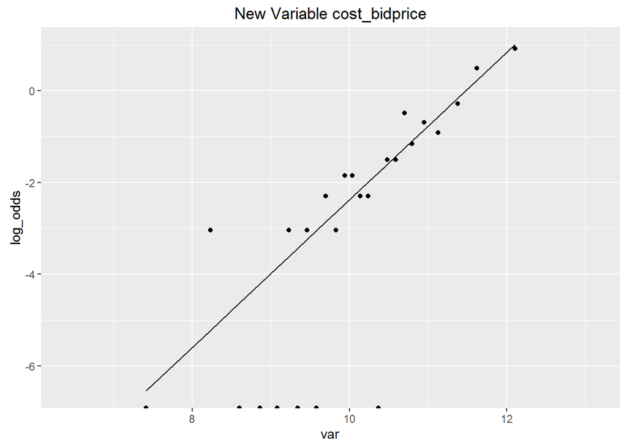

```
##      var   prob_win  n       odds   log_odds   pred_prob pred_log_odds
## 1   7.41 0.00000000 22 0.00000000       -Inf 0.001446181    -6.5373817
## 2   8.23 0.04545455 22 0.04761905 -3.0445224 0.005372836    -5.2210121
## 3   8.60 0.00000000 22 0.00000000       -Inf 0.009688879    -4.6270405
## 4   8.86 0.00000000 22 0.00000000       -Inf 0.014634152    -4.2096550
## 5   9.08 0.00000000 22 0.00000000       -Inf 0.020704494    -3.8564827
## 6   9.23 0.04545455 22 0.04761905 -3.0445224 0.026193959    -3.6156833
## 7   9.34 0.00000000 22 0.00000000       -Inf 0.031095674    -3.4390972
## 8   9.46 0.04545455 22 0.04761905 -3.0445224 0.037454383    -3.2464577
## 9   9.58 0.00000000 22 0.00000000       -Inf 0.045052914    -3.0538183
## 10  9.70 0.09090909 22 0.10000000 -2.3025851 0.054106338    -2.8611788
## 11  9.83 0.04545455 22 0.04761905 -3.0445224 0.065835946    -2.6524861
## 12  9.94 0.13636364 22 0.15789474 -1.8458267 0.077565050    -2.4758999
## 13 10.04 0.13636364 22 0.15789474 -1.8458267 0.089858240    -2.3153670
## 14 10.14 0.09090909 22 0.10000000 -2.3025851 0.103880352    -2.1548342
## 15 10.24 0.09090909 22 0.10000000 -2.3025851 0.119802549    -1.9943013
## 16 10.37 0.00000000 22 0.00000000       -Inf 0.143611972    -1.7856086
## 17 10.48 0.18181818 22 0.22222222 -1.5040774 0.166724386    -1.6090224
## 18 10.59 0.18181818 22 0.22222222 -1.5040774 0.192719376    -1.4324362
## 19 10.70 0.38095238 21 0.61538462 -0.4855078 0.221689108    -1.2558501
## 20 10.80 0.23809524 21 0.31250000 -1.1631508 0.250618340    -1.0953172
## 21 10.95 0.33333333 21 0.50000000 -0.6931472 0.298485990    -0.8545179
## 22 11.13 0.28571429 21 0.40000000 -0.9162907 0.362262263    -0.5655587
## 23 11.38 0.42857143 21 0.75000000 -0.2876821 0.459035402    -0.1642265
## 24 11.62 0.61904762 21 1.62500000  0.4855078 0.555039162     0.2210524
## 25 12.11 0.71428571 21 2.50000000  0.9162907 0.732562642     1.0076635
```

```r
plot_continuous(convert_to_factor(df$cost_bidprice,25), df$win_bid, i = 1, 'New Variable cost_bidprice')
```

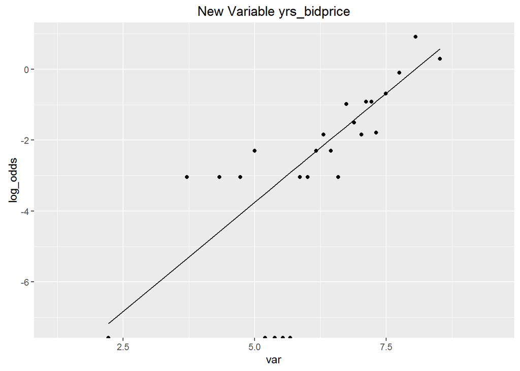

```
##     var   prob_win  n       odds    log_odds   pred_prob pred_log_odds
## 1  2.22 0.00000000 22 0.00000000        -Inf 0.000766717   -7.17262579
## 2  3.71 0.04545455 22 0.04761905 -3.04452244 0.004775739   -5.33941930
## 3  4.33 0.04545455 22 0.04761905 -3.04452244 0.010184934   -4.57660854
## 4  4.73 0.04545455 22 0.04761905 -3.04452244 0.016553388   -4.08447257
## 5  5.00 0.09090909 22 0.10000000 -2.30258509 0.022926223   -3.75228079
## 6  5.20 0.00000000 22 0.00000000        -Inf 0.029135974   -3.50621281
## 7  5.38 0.00000000 22 0.00000000        -Inf 0.036098019   -3.28475162
## 8  5.54 0.00000000 22 0.00000000        -Inf 0.043609252   -3.08789723
## 9  5.68 0.00000000 22 0.00000000        -Inf 0.051385345   -2.91564964
## 10 5.86 0.04545455 22 0.04761905 -3.04452244 0.063317154   -2.69418845
## 11 6.01 0.04545455 22 0.04761905 -3.04452244 0.075185314   -2.50963747
## 12 6.17 0.09090909 22 0.10000000 -2.30258509 0.090069791   -2.31278308
## 13 6.31 0.13636364 22 0.15789474 -1.84582669 0.105218964   -2.14053549
## 14 6.45 0.09090909 22 0.10000000 -2.30258509 0.122572902   -1.96828790
## 15 6.59 0.04545455 22 0.04761905 -3.04452244 0.142333760   -1.79604031
## 16 6.74 0.27272727 22 0.37500000 -0.98082925 0.166381944   -1.61148932
## 17 6.89 0.18181818 22 0.22222222 -1.50407740 0.193576176   -1.42693833
## 18 7.03 0.13636364 22 0.15789474 -1.84582669 0.221889206   -1.25469074
## 19 7.12 0.28571429 21 0.40000000 -0.91629073 0.241594016   -1.14396015
## 20 7.22 0.28571429 21 0.40000000 -0.91629073 0.264847036   -1.02092615
## 21 7.31 0.14285714 21 0.16666667 -1.79175947 0.286959821   -0.91019556
## 22 7.49 0.33333333 21 0.50000000 -0.69314718 0.334314677   -0.68873437
## 23 7.75 0.47619048 21 0.90909091 -0.09531018 0.408819900   -0.36884599
## 24 8.06 0.71428571 21 2.50000000  0.91629073 0.503139805    0.01255938
## 25 8.52 0.57142857 21 1.33333333  0.28768207 0.640725809    0.57851575
```

```r
plot_continuous(convert_to_factor(df$yrs_bidprice,25), df$win_bid, i = 1, 'New Variable yrs_bidprice')
```

The assumption of linearity of log odds holds relatively well

At this step we have created 3 new potential variables (two interactions and one continuous versions of the binary competitor variables) to the dataset and we now look at modeling the data… Continued on the modeling page